# Examen Intra

René Picard

2024-02-22

```r
load("C:/Users/kf891141/Desktop/Stats-Syntese/Examen_Intra/Mandragore_1.RData")
load("C:/Users/kf891141/Desktop/Stats-Syntese/Examen_Intra/Mandragore_2.RData")
```

Chargement des librairy

```r
library(psych)
```

# Question 1

Entrée des données

```r
attach(Mandragore_1)
```

Sortie: Hemisphere = {Sud, Nord} Feuilles = {Nombres de feuilles} Hauteur = {Hauteur du plan (en pouces)}

Petite visualisation des données

```r
View(Mandragore_1)
summary(Mandragore_1)
```

```
##  Hemisphere    Feuilles        Hauteur
##  Nord:150   Min.   :11.00   Min.   : 1.060
##  Sud :150   1st Qu.:23.00   1st Qu.: 1.930
##             Median :25.00   Median : 2.865
##             Mean   :25.29   Mean   : 4.193
##             3rd Qu.:28.00   3rd Qu.: 4.492
##             Max.   :37.00   Max.   :43.360
```

## (i) Est-ce que la croissance de la plante est influencée par l’hémisphère?

Observons les données de la hauteur par rapport à l’hémisphère (et ensuite du nombre de feuilles par arbre)

```r
psych::describeBy(Hauteur, group = Hemisphere)#si l'on écrit cette ligne dans la console, la sortie apparait bien, si on l'écrit dans cette cellule, la sortie est très laide...
```

```
##
##  Descriptive statistics by group
## group: Nord
##    vars   n mean   sd median trimmed  mad  min   max range skew kurtosis   se
## X1    1 150 3.94 4.63   2.76    2.97 1.47 1.06 43.36  42.3 5.08    35.08 0.38
## ------------------------------------------------------------
## group: Sud
##    vars   n mean sd median trimmed  mad  min   max range skew kurtosis   se
## X1    1 150 4.45  4      3    3.63 1.79 1.09 30.81 29.72 2.85     12.1 0.33
```

Dans la sortie (console), on peut observer des écart-type très proche, donc des variances semblables. Un nombre d’observations égaux.

Regardons un box-plot des données:

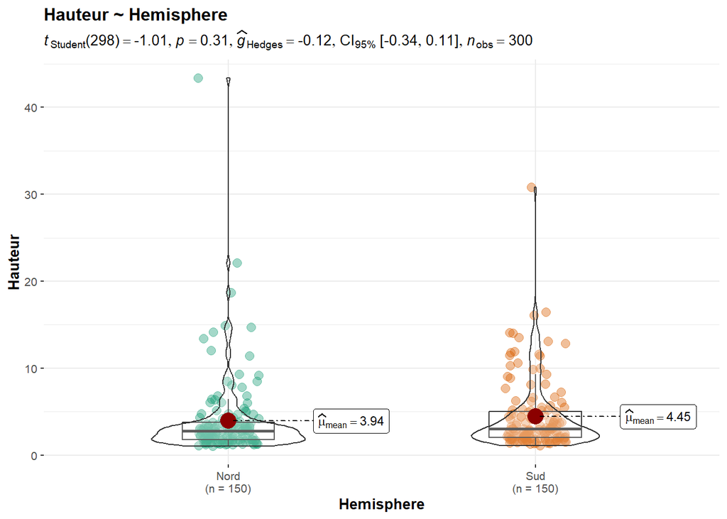

```r
ggstatsplot::ggbetweenstats(
data = Mandragore_1, x = Hemisphere, y = Hauteur,
title = "Hauteur ~ Hemisphere",
mean.ci = TRUE,
type="p",
var.equal = TRUE,
bf.message = FALSE,
)
```

Les données sont très dense entre 0 et 5 pouces de hauteur, avec une certaine dispersion entre 5 et 15 pouces. Essayons une transformation des données. Essayons une transformation logarithmique.

```r
Mandragore_1$logHauteur <- log(Hauteur)
attach(Mandragore_1)
```

```
## Les objets suivants sont masqués depuis Mandragore_1 (pos = 3):
##
##     Feuilles, Hauteur, Hemisphere
```

Maintenant réessayons le graphique:

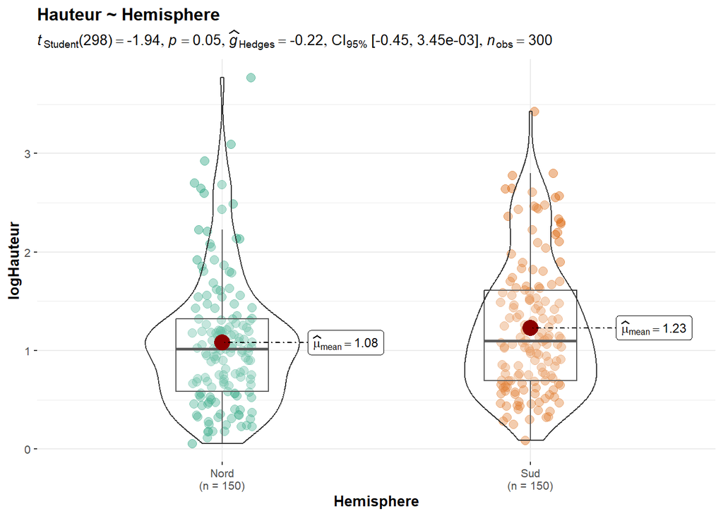

```r
ggstatsplot::ggbetweenstats(
data = Mandragore_1, x = Hemisphere, y = logHauteur,
title = "Hauteur ~ Hemisphere",
mean.ci = TRUE,
type="p",
var.equal = TRUE,
bf.message = FALSE,
)
```

```r
psych::describeBy(Hauteur, group = Hemisphere)
```

```
##
##  Descriptive statistics by group
## group: Nord
##    vars   n mean   sd median trimmed  mad  min   max range skew kurtosis   se
## X1    1 150 3.94 4.63   2.76    2.97 1.47 1.06 43.36  42.3 5.08    35.08 0.38
## ------------------------------------------------------------
## group: Sud
##    vars   n mean sd median trimmed  mad  min   max range skew kurtosis   se
## X1    1 150 4.45  4      3    3.63 1.79 1.09 30.81 29.72 2.85     12.1 0.33
```

La répartition des données est bien meilleure (visuellement). Les variances semblent être plus égales, malgré quelques valeurs extrêmes pour l’hémisphère Nord et une valeur extrême pour l’hémisphère Sud. Vu que nous avons déjà fait une transformation logarithmique et que celle-ci est résistante aux valeurs extrêmes, nous allons garder les dites valeurs.

Vu que les variances sont à peu près égales, que le nombre d’observations égaux pour les 2 hémisphères. Nous allons faire un test t pour vérifier si la croissance de la plante est influencée par l’hémisphère, ou en d’autres mots, si l’on doit rejeté l’hyphothèse nulle $H_0: \mu_{Nord} = \mu_{Sud}$ vs $H_0: \mu_{Nord} \neq \mu_{Sud}$. Et l’on va prendre un risque de première espèce $\alpha = 0.05$.

```r
t.test(logHauteur ~ Hemisphere,var.equal=T)
```

```
##
##  Two Sample t-test
##
## data:  logHauteur by Hemisphere
## t = -1.9378, df = 298, p-value = 0.0536
## alternative hypothesis: true difference in means between group Nord and group Sud is not equal to 0
## 95 percent confidence interval:
##  -0.30231814  0.00233616
## sample estimates:
## mean in group Nord  mean in group Sud
##           1.081772           1.231763
```

Le test de student nous donne une p-valeur de 0.0536, ce qui est plus grand que notre $\alpha = 0.05$. Donc nous ne pouvons rejeter l’hypothèse nulle qui est qu’il n’y a pas de différence entre les moyennes de la croissances des feuilles entre l’hémisphère Nord et l’hémisphère Sud.

Maintenant regardons pour le nombre de feuilles par arbres par rapport à chaque hémisphère

```r
psych::describeBy(Feuilles, group = Hemisphere)
```

```
##
##  Descriptive statistics by group
## group: Nord
##    vars   n  mean   sd median trimmed  mad min max range skew kurtosis   se
## X1    1 150 25.17 3.76     25   25.16 2.97  14  37    23 0.13     0.26 0.31
## ------------------------------------------------------------
## group: Sud
##    vars   n  mean   sd median trimmed  mad min max range  skew kurtosis   se
## X1    1 150 25.42 4.99     25   25.56 4.45  11  37    26 -0.18    -0.21 0.41
```

L’écart-type semble assez différent, vérifions avec 1 graphique

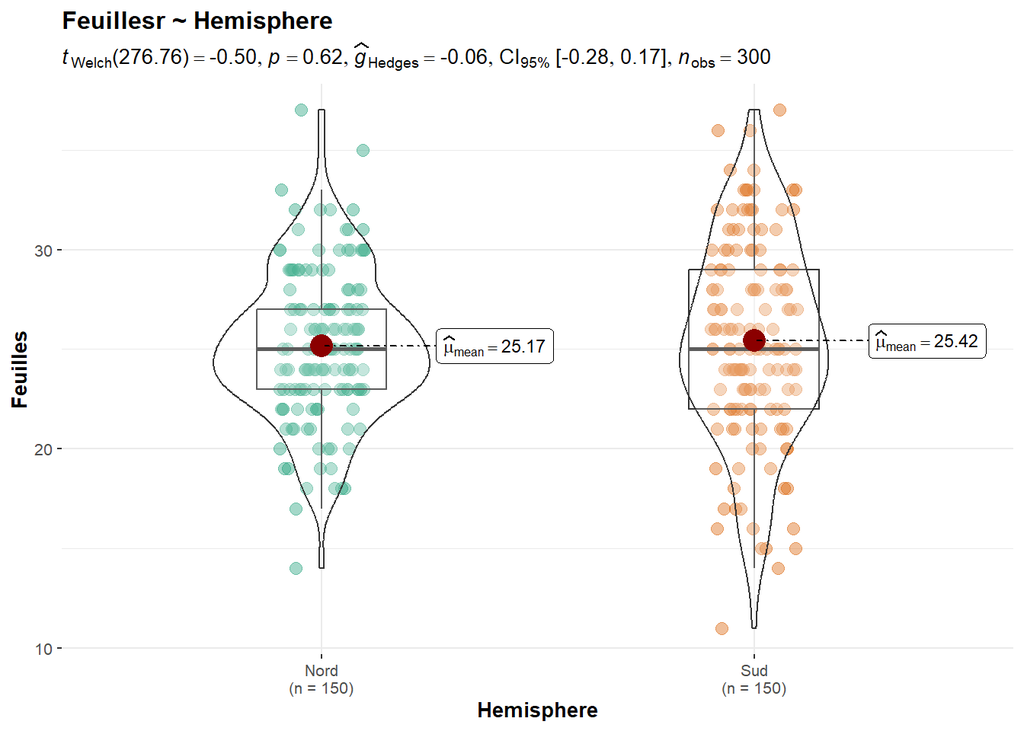

```r
ggstatsplot::ggbetweenstats(
data = Mandragore_1, x = Hemisphere, y = Feuilles,
title = "Feuillesr ~ Hemisphere",
mean.ci = TRUE,
type="p",
var.equal = FALSE,
bf.message = FALSE,
)
```

La variance ne semble pas très différente (même s’il y plus de valeurs extrêmes au Sud). En plus la médiane semble presque égale, pareil pour la moyenne. Pour améliorer les variances des 2 groupes, éliminons les valeurs en dessous de 15 feuilles.

```r
which(Mandragore_1$Feuilles < 15)
```

```
## [1] 126 181 274
```

On enlève ces données

```r
Mandragore_1b <- Mandragore_1[-c(126,181,274),]
which(Mandragore_1b$Feuilles < 15)#vérification
```

```
## integer(0)
```

Donc on revérifie la variance:

```r
psych::describeBy(Mandragore_1b$Feuilles, group = Mandragore_1b$Hemisphere)
```

```
##
##  Descriptive statistics by group
## group: Nord
##    vars   n  mean   sd median trimmed  mad min max range skew kurtosis  se
## X1    1 149 25.24 3.66     25    25.2 2.97  17  37    20 0.27     0.06 0.3
## ------------------------------------------------------------
## group: Sud
##    vars   n  mean   sd median trimmed  mad min max range  skew kurtosis   se
## X1    1 148 25.59 4.79     25   25.67 4.45  15  37    22 -0.04    -0.44 0.39
```

Numériquement, les variance sont encore très inégales.

On refait le graphique:

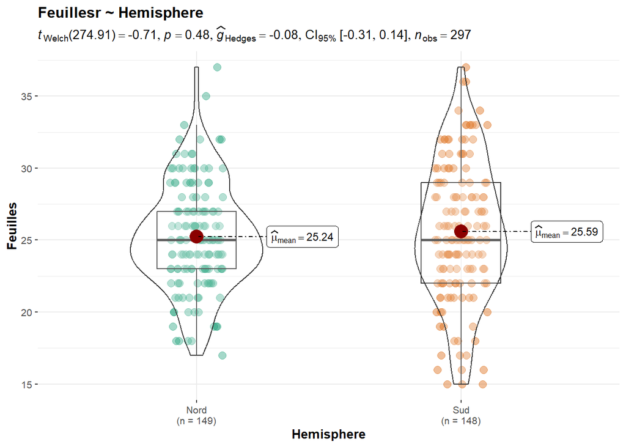

```r
ggstatsplot::ggbetweenstats(
data = Mandragore_1b, x = Hemisphere, y = Feuilles,
title = "Feuillesr ~ Hemisphere",
mean.ci = TRUE,
type="p",
var.equal = FALSE,
bf.message = FALSE,
)
```

Les données sont beaucoup mieux répartit et la variances, bien qu’inégale, sont semblable. Nous allons donc prendre le résultat de la p-valeur qui est fait avec le ggstatplots::ggbetweenstats avec $\alpha = 0.05$, pour tester $H_0: \mu_{Nord} = \mu_{Sud}$ vs $H_0: \mu_{Nord} \neq \mu_{Sud}$. Vu que les variances sont inégales, c’est un test de t de Welch qui est fait et nous avons comme p-valeur 0.48 qui est bien au-dessus de $\alpha = 0.05$. Donc on ne rejette pas $H_0$ qui émet l’hypothèse que les moyennes du nombre de feuilles est le même au Sud comme au Nord.

Donc avec les 2 comparaisons, c’est-à-dire le nombre de feuilles et la hauteur des feuilles, on peut conclure qu’il n’y a pas d’effet sur la croissance des plans pour chaque hémisphère.

## (ii)

Si la chercheuse voulait tenter de montrer un effet. Elle pourrait comparer le temps de croissance jusqu’à maturité entre les plans au Sud comparé au Nord

# Question 2

```r
View(Mandragore_2)
attach(Mandragore_2)
```

Sortie: Id = {1 à 15} SansEngrais = {qté} AvecEngrais = {qté}

## (i) Est-ce que le ZIK a un effet sur la croissance de la Mandragore?

Tout d’abord, faisons une visulatisation numérique des données

```r
summary(Mandragore_2)
```

```
##        Id        SansEngrais     AvecEngrais
##  Min.   : 1.0   Min.   :0.400   Min.   :-1.000
##  1st Qu.: 4.5   1st Qu.:1.550   1st Qu.: 1.750
##  Median : 8.0   Median :3.200   Median : 2.700
##  Mean   : 8.0   Mean   :3.207   Mean   : 3.267
##  3rd Qu.:11.5   3rd Qu.:4.650   3rd Qu.: 5.150
##  Max.   :15.0   Max.   :6.400   Max.   : 7.100
```

Regardons numériquement les données:

```r
psych::describe(AvecEngrais)
```

```
##    vars  n mean   sd median trimmed  mad min max range skew kurtosis   se
## X1    1 15 3.27 2.15    2.7     3.3 1.78  -1 7.1   8.1 0.01    -0.92 0.56
```

```r
psych::describe(SansEngrais)
```

```
##    vars  n mean   sd median trimmed  mad min max range skew kurtosis   se
## X1    1 15 3.21 1.84    3.2    3.18 2.52 0.4 6.4     6 0.17    -1.37 0.47
```

On voit que les données montre un écart-type assez proche. Par contre, le min de “avec engrais” est négatif et il y a en effet une valeur négative. Vu qu’il est impossible qu’un plan est un poids négatif et vu que nous n’avons pas d’instruction de quoi faire en cas de valeur négative dans nos données, nous allons retiré ce poids.

```r
which(Mandragore_2$AvecEngrais <0)
```

```
## [1] 8
```

```r
Mandragore_2b <- Mandragore_2[-c(8),]
which((Mandragore_2b$AvecEngrais < 0))
```

```
## integer(0)
```

Bien qu’il soit pertinent de garder l’Id, vu que chaque plante est identique génétiquement, nous allons ignorer cette variable et ajouter une variable poids. Et inventer une variables Engrais (1= avec, 0 = sans). Nous allons faire cela pour pouvoir comparer nos variance

```r
length(Id)
```

```
## [1] 15
```

```r
Poids <- rep(NA, 2*15-2)
Engrais <- rep(NA, 2*15-2)
for(i in 1:14){
  Poids[i] <- Mandragore_2b$SansEngrais[i]
  Engrais[i] <- 0
}

for(i in 1:14){
  Poids[i+length(Id)-1] <- Mandragore_2b$AvecEngrais[i]
  Engrais[i+length(Id)-1] <- 1
}
```

Maintenant on fait une description numérique pour notre variable poids en fonction de l’engrais:

```r
psych::describeBy(Poids, group = Engrais)
```

```
##
##  Descriptive statistics by group
## group: 0
##    vars  n mean   sd median trimmed  mad min max range skew kurtosis  se
## X1    1 14 3.13 1.88   3.15    3.08 2.52 0.4 6.4     6 0.27    -1.38 0.5
## ------------------------------------------------------------
## group: 1
##    vars  n mean   sd median trimmed  mad min max range skew kurtosis  se
## X1    1 14 3.57 1.87   2.95    3.45 1.85 1.5 7.1   5.6 0.41    -1.43 0.5
```

On voit un écart-type quasi exacte (1.88 vs 1.87), par contre les minimum de chacun sont assez différent.

Maintenant on fait un graphique:

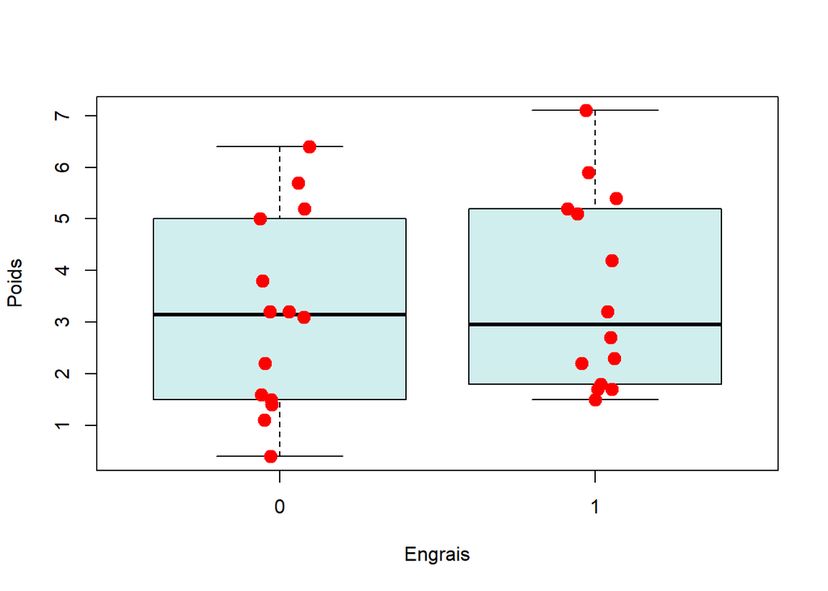

```r
boxplot(Poids ~ Engrais, col = "lightcyan2")
stripchart(Poids ~ Engrais, vertical = TRUE,
method = "jitter", add = TRUE, pch = 20, cex=2.2,col = 'red')
```

Les variances semblent être semblable (ce qui était confirmé numériquement). Il est par contre difficile de trouver une différence quelconque avec ces 2 boxplot. Vu que les variance sont semblables, faisons un test t de student pour vérifier si la moyenne des poids est égale selon l’engrais (hypothèse nulle) contre si les moyennes sont différentes. Nous allons prendre un risque de première espèce ($\alpha$) de 5%

```r
t.test(Poids ~ Engrais, var.equal = TRUE)
```

```
##
##  Two Sample t-test
##
## data:  Poids by Engrais
## t = -0.62493, df = 26, p-value = 0.5375
## alternative hypothesis: true difference in means between group 0 and group 1 is not equal to 0
## 95 percent confidence interval:
##  -1.899504  1.013790
## sample estimates:
## mean in group 0 mean in group 1
##        3.128571        3.571429
```

La p-valeur du test t est de 0.5375. Qui est bien au-dessus de 5%. Donc nous ne pouvons rejeter l’hypothèse nulle qui est que la moyenne des poids avec engrais est égale à la moyenne des poids sans engrais.

## (ii)

Encore une fois, la chercheuse devrait regarder le temps de maturation sous engrais contre sans engrais. Aussi, elle pourrait observer combien d’eau est consommé par les 2 plantes pendant leur cycle de vie. Ce sont des informations pertinentes pour vérifier s’il y a une différence significative entre les 2 groupes.

## (iii)

Premièrement, ne pas ajouter une observation négative, à moins d’expliquer le sens de cette observation négaitve. Ensuite, choisir l’endroit où est cultivé le plans de manière randomisé, car peut-être que cela n’a pas été prise en compte lors de l’expérience initiale et cela peut affecté la croissance du plant (par exemple, plus de soleil à un endroit qu’à un autre endroit).